# Embryonic development demo Notebook

##### Zhang Yi synapse@pku.edu.cn

##### 20220308

#### Introduction

In this vignette we show EpiTrace age application to scATAC of human embryonic development scATAC/LiCAT-seq sample. Data is from NCBI SRA and in-house.

**Reference**  
Wu J, Xu J, Liu B, Yao G, Wang P, Lin Z, Huang B, Wang X, Li T, Shi S, Zhang N, Duan F, Ming J, Zhang X, Niu W, Song W, Jin H, Guo Y, Dai S, Hu L, Fang L, Wang Q, Li Y, Li W, Na J, Xie W, Sun Y. Chromatin analysis in human early development reveals epigenetic transition during ZGA. Nature. 2018 May;557(7704):256-260. doi: 10.1038/s41586-018-0080-8. Epub 2018 May 2. Erratum in: Nature. 2018 Aug;560(7718):E27. PMID: 29720659.  
Liu L, Leng L, Liu C, Lu C, Yuan Y, Wu L, Gong F, Zhang S, Wei X, Wang M, Zhao L, Hu L, Wang J, Yang H, Zhu S, Chen F, Lu G, Shang Z, Lin G. An integrated chromatin accessibility and transcriptome landscape of human pre-implantation embryos. Nat Commun. 2019 Jan 21;10(1):364. doi: 10.1038/s41467-018-08244-0. PMID: 30664750; PMCID: PMC6341076.  
Wei He, Yuan Wei, Xiaoli Gong, Luyuan Chang, Wan Jin, Ke Liu, Xinghuan Wang, Yu Xiao, Wenjing Zhang, Qiong Chen, Kai Wu, Lili Liang, Jia Liu, Yawen Chen, Huanhuan Guo, Wenhao Chen, Jiexia Yang, Yiming Qi, Wei Dong, Meng Fu, Xiaojuan Li, Jiusi Liu, Yi Zhang, Aihua Yin. Developmentally Delayed Epigenetic Reprogramming Underlying the Pathogenesis of Preeclampsia. bioRxiv 2020.05.08.085290; doi: https://doi.org/10.1101/2020.05.08.085290

#### Data loading

First we load the data via:

```r
library(dplyr)
library(tidyr)
library(readr)
library(GenomicRanges)
library(reshape2)
library(openxlsx)
library(ggplot2)
library(Matrix)
library(EpiTrace)
library(Seurat)
library(SeuratObject)
library(ggtree)
library(EnsDb.Hsapiens.v86)
library(patchwork)
library(ArchR)
library(Signac)
rm(list=ls())
data("clock_gr_list")
load('/Users/wing/Desktop/Eulerian/文件/内部研发项目/CLOCK_CANCER/Clock_Evolution/data/scATAC_human_embryo/embryo_human_scATAC.raw.Rdata') # this is hg19
load('/Users/wing/Desktop/Eulerian/文件/内部研发项目/CLOCK_CANCER/Clock_Evolution/data/scATAC_human_embryo/embryo_human_scATAC.raw.coverage.Rdata')
```

We have already processed the data into several data.frames : phenoData, a data set containing meta-data of the cells featureData, a data set containining meta-data of the peaks coverage_mat_wide, the count matrix (with additional ‘origin’ column)

#### Creating the EpiTrace object

We prepare the peak-set and count matrix using `Init_Peakset` and `Init_Matrix`.

```r
featureData <- left_join(featureData,window_annotation%>%dplyr::select(chr,start,end,peakid))
featureData %>% unique()  -> peakset
initiated_peaks <- Init_Peakset(peakset)
initiated_mm <- Init_Matrix(cellname = rownames(phenoData),peakname = initiated_peaks$peakId,matrix = t(coverage_mat_wide[rownames(phenoData),2:ncol(coverage_mat_wide)]))
epitrace_obj <- EpiTrace_prepare_object(initiated_peaks,initiated_mm,ref_genome = 'hg19',non_standard_clock = F,clock_gr_list = clock_gr_list,qualnum=1)
```

```
ref clock list is set to be standard (Homo sapiens, hg19)
Input peakset is set to be hg19
```

```
[1] 0
```

```
add ChronologyClock
good quality cells 70 and peaks 19969
```

```
[1] 0
```

```
add AllClock
good quality cells 70 and peaks 20052
```

```
[1] 0
```

```
Performing TF-IDF normalization
Running SVD
Warning in irlba(A = t(x = object), nv = n, work = irlba.work) :
  You're computing too large a percentage of total singular values, use a standard svd instead.
Scaling cell embeddings
```

```r
DefaultAssay(epitrace_obj) <- 'peaks'
```

#### Basic pre-processing

We firstly annotate the cells by adding additional metadata into the object.

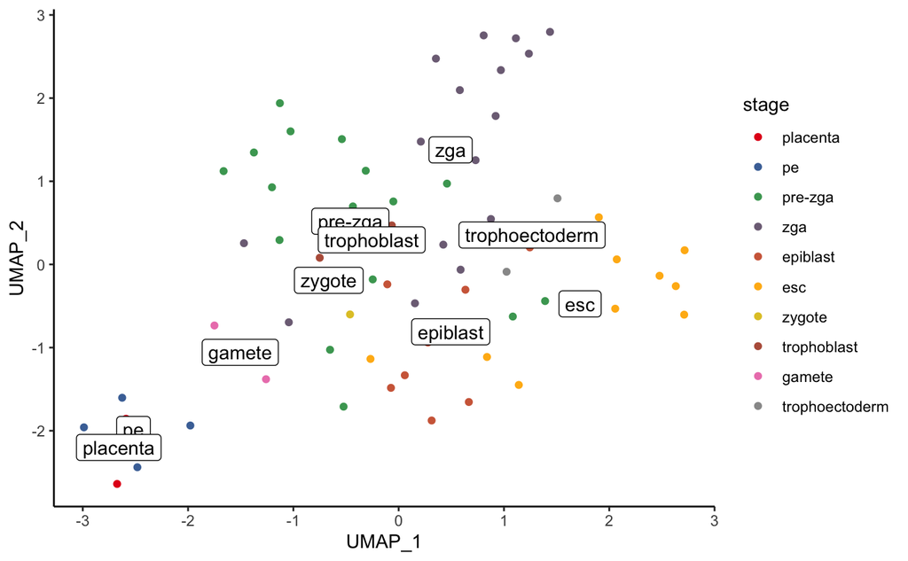

#### Estimate age and phylogeny

We estimate the EpiTrace age, and phylogeny based on EpiTrace age, by using the `RunEpiTraceAge` and `RunEpiTracePhylogeny` commands.

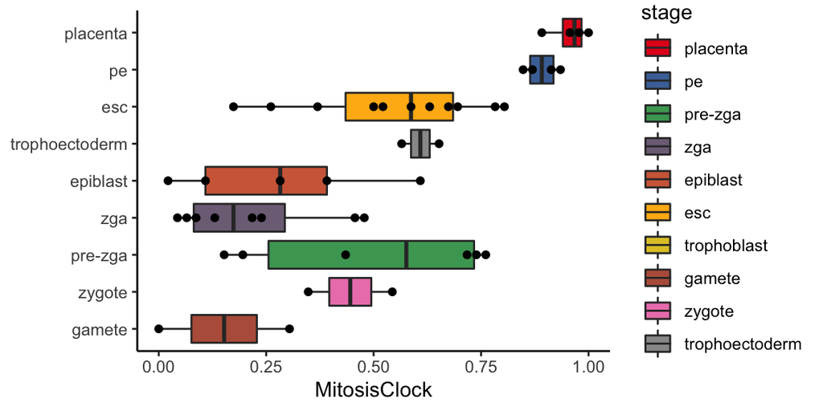

```r
ggplot(epitrace_obj_age_estimated@meta.data[epitrace_obj_age_estimated@meta.data$stage %ni% 'trophoblast' & !grepl('3PN',epitrace_obj_age_estimated$tissue),],aes(y=stage,x=EpiTraceAge_MitosisClock)) + geom_boxplot(aes(fill=stage)) + ggbeeswarm::geom_beeswarm() + scale_fill_manual(values=colors_plot) +  scale_color_manual(values=colors_plot) + theme_classic() + xlab('MitosisClock') + theme(axis.title.y = element_blank())
```

Phylogeny is hard to estimate here because cell number is very few.